# Laboratorio práctico 4 [GEO622]

MSc. José A. Lastra

2021-05-06

# Introducción

La función del siguiente documento es apoyar el desarrolo de las clases del curso GEO-622, vinculadas al uso y manipulación de geo-información empleando diferentes plataformas SIG.

Esta guía es un apoyo y no representa un reemplazo al contenido de las clases sincrónicas.

## 1.- Creación Geodatabase

La **Geodatabase** es un modelo que permite el almacenamiento físico de la información geográfica, ya sea en archivos dentro de un sistema de ficheros o en una colección de tablas en un Sistema Gestor de Base de Datos (Microsoft Access, Oracle, Microsoft SQL Server, IBM DB2 e Informix).

Es fácil crear un geodatabase y agregarle comportamiento, ya que, el uso de las herramientas de administración de datos de ArcGIS Desktop no requiere programación alguna. Al consultar y editar la geodatabase en ArcMap o ArcCatalog, que son las aplicaciones de edición, análisis y creación de mapas a partir de los datos, puede aprovechar los datos y el comportamiento de la geodatabase sin necesidad de realizar ninguna operación de personalización (Esri, 2012).

### 1.1.- Creación desde ArcCatalog

En el menú de inicio, localice el ícono de **ArcCatalog** y de clic para iniciar el programa. Para crear una Geodatabase (GDB), debe posicionarse sobre el directorio deseado de clic derecho y localice la opción **Nuevo**. Donde podrá identificar dos opciones principales de GDB:

1. Personal Geodatabase
2. File Geodatabase

[figure not shown]

En el caso de la **Personal GDB**, esta tiene un límite de espacio funcional de 2 GB de almacenamiento y se basa en la estructura de la base de datos Access (MDB). Permite la manipulación externa al poder conectar y manipular mediante otras aplicaciones, como por ejemplo R.

Una **Personal GDB** es una buena alternativa para generar salidas de procesos de análisis espacial, no obstante en la mayoría de los casos resulta más conveniente el trabajo sobre una **File GDB**.

Una **File GDB** permite a los usuarios comprimirla, crear índices espaciales para el manejo adecuado de los geo-datos, manejo raster y edición más eficiente estos últimos. Además, a diferencia de una Personal GDB, esta permite el trabajo con grandes volúmenes de datos llegando a un tamaño máximo de 1 TB por dataset hasta los 256 TB.

Seleccione para este caso la opción **File Geodatabase** y localice la base de datos en su directorio. Renombre la base de datos a *“GDB_curso”*

## 2.- Creación y configuración de dominios

### 2.1.- Manual

La creación de un dominio implica una estandarización de una base de datos que otorga valores permitidos para una tabla o feature class dentro de la misma. Esto asegura la integridad en el proceso de llenado del feature o tabla de atributos, evitando errores de digitación.

Para la creación manual de dominios considere la siguiente tabla de datos de nombre **ARTE_PESCA**:

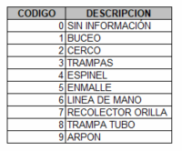

Para incorporar un dominio, seleccione su GDB de clic derecho y elija las propiedades del archivo. En la ventana emergente, seleccione la pestaña **Dominios**.

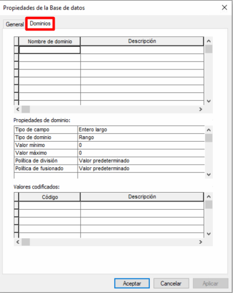

Para incorporar un dominio nuevo escriba el nombre en la columna **Nombre de dominio**; en este caso el nombre del dominio corresponde a *ARTE DE PESCA*. En la descripción ponga un texto breve indicando las características del dominio.

En las propiedades del dominio, debe seleccionar el tipo de campo que almacenará la información (ej. Numérico, texto, etc.) y también el tipo de dominio a trabajar (Códigos o rangos). Para este caso elija la opción **entero corto**, **Valores codificados** y deje las siguientes opciones por defecto.

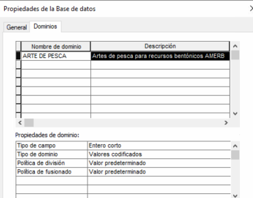

Una vez realizado esto, proceda a incorporar los códigos en la sección **Valores codificados**, siguiendo los valores de la tabla. La descripción debe realizarse como se quiere visualizar posteriormente en las tablas y features que contendrán el dominio. Una vez finalizado, acepte las modificaciones.

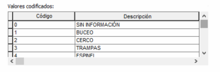

### 2.2.- Importación externa

Adicional al proceso de creación manual, usted puede importar dominios externos almacenados en una tabla ordenada que disponga de las columnas de códigos y descripción debidamente identificadas por el usuario. Tenga en consideración que de acuerdo al formato nativo (DBF, XLS, INFO) y al tipo de almacenamiento del dato en la tabla el dominio se configurará automáticamente (string, short integer, long integer, double, etc.). Esta opción resulta óptima cuando se debe ingresar un alto número de códigos, pero puede requerir una configuración previa, dependiendo de la base de datos donde se pretenda acoplar o como se ha diagramado la misma.

Para este ejemplo, considere la tabla **RECURSOS.dbf** que se encuentra alojada en el directorio de trabajo:

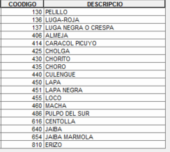

Para importar los dominios completos vaya a la pestaña de **ArcToolbox** y localice el menú **Herramientas de administración de datos/Dominios/Tabla a Dominio**.

En la ventana emergente debe seleccionar la tabla de interés, en este caso **RECURSOS**, e identificar el campo que contiene los códigos y las descripciones. En la sección **Espacio de trabajo de entrada** debe colocar el GDB sobre el que desea aplicar el dominio, en este caso el GDB creado al principio del manual. Finalmente, configure el nombre y la descripción del dominio como la opción de actualización, en este caso **APPEND**.

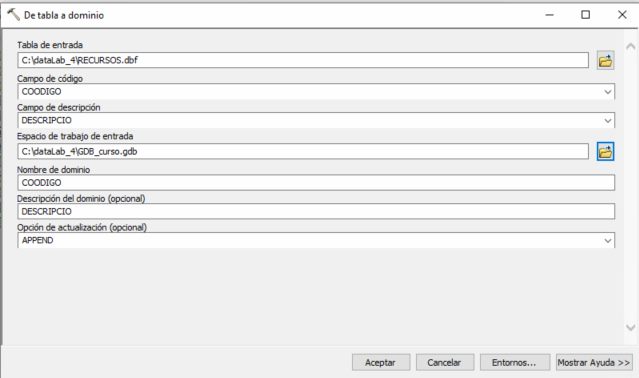

Luego de incorporar los input, de ok y revise si los dominios se incorporaron correctamente en su base de datos. Dando clic derecho sobre la base y vaya a las propiedades .

## 3.- Feature Datasets (datasets de entidades)

Un feature dataset es una colección de capas espaciales relacionadas que comparten un sistema de coordenadas común. Son empleados para integrar espacial o temáticamente feature class con el fin de generar productos adicionales como topologías, redes geométricas o parcelas.

### 3.1.- Creación feature datasets

Para crear un feature de clic derecho sobre su GDB y vaya a **Nuevo/Dataset de entidades**, en la ventana emergente debe poner un nombre al feature dataset a crear en este caso **AMERB**. Considere que el nombre no debe partir con números ni debe contener espacios e idealmente debe excluir caracteres especiales.

En la siguiente ventana, usted deberá elegir el sistema de coordenadas sobre el cuál estarán configuradas todas las capas espaciales a almacenar . Para este caso el sistema será **WGS 1984 UTM Zone 18S**, puede hacer búsqueda del sistema directamente en la ventana.

Luego, en caso de que se disponga, usted podrá seleccionar un elipsoide de coordenadas verticales. Esta información puede resultar útil cuando se dispone de una capa de información **“Z”** conteniendo elevación o batimetría; para el caso deje sin rellenar.

En la siguiente ventana se definen los umbrales de tolerancia, los que pueden ser definidos por la escala de origen de las capas vectoriales. Para el caso deje los valores por defecto.

Revise ahora su directorio y debe encontrar el nuevo feature dataset.

## 4.- Crear y administrar Feature Class (Clase de entidad).

La creación de un feature class puede venir desde diferentes fuentes, una de ellas puede ser la creación manual de su estructura (punto, línea, polígono) y de su base de datos (atributos alfanuméricos). Un feature class puede ir tanto en el directorio raíz del GDB como en un feature dataset.

### 4.1.- Manual

Para este caso, usted creará una capa de puntos que representará los centroides de las áreas de manejo en el feature dataset **AMERB**. Vaya al feature dataset indicado y de clic derecho sobre el mismo y seleccione **Nuevo/Entidad de clase**. En la ventana desplegada, debe indicar el nombre,**PART_SSP_POINT_AMERB**, de la capa junto con el alias, el tipo de geometría del elemento (punto, línea o polígono) y propiedades específicas como almacenamiento de elevación o dirección.

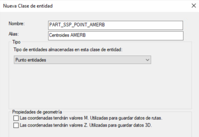

En la siguiente ventana uno puede configurar una palabra clave para el nuevo objeto que le dice a la base de datos dónde y qué formato de almacenamiento emplear para el elemento. Para este ejemplo utilice la opción por defecto.

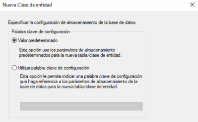

En la siguiente ventana deberá configurar los atributos de la tabla del feature class considerando el tipo de dato, nombre y alias del campo. Para todos los feature class se generan automáticamente dos campos: (i) **OBJECTID** que es un número correlativo de 0 a N, y (ii) **Shape** que da a conocer la geometría del objeto.

Cree el campo **AMERBID** y asigne el alias *“Código AMERB”*. Se puede indicar el dominio para la capa espacial en caso de haberlo preconfigurado y también puede establecer si permitirá valores nulos (filas vacías) para ese campo en particular. En este caso el campo será **Entero Largo**, sin valores nulos (al ser un código) y no se le asignará un dominio. Si usted dispone de campos ya configurados en otra tabla, también puede importarlos directamente en esta sección.

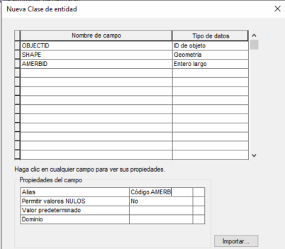

Con el feature de puntos ya creado usted podría poblarlo con información en el ambiente de trabajo a partir de edición manual. En este caso, se poblará el feature con información proveniente de la capa **PART_SSP_POINT_AMERB.shp** alojada en su directorio de trabajo. De clic derecho sobre el feature class creado anteriormente y vaya a **Cargar/Cargar datos**.

En la ventana que se despliega, localice el archivo mencionado para poblar el feature y oprima **agregar** para agregarlo al listado. Puede agregar tanta información como campos de atributos tenga el elemento a poblar.

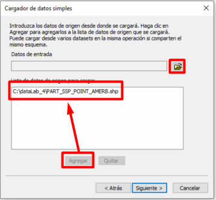

Posteriormente, deberá asignar los campos a poblar de acuerdo al tipo de dato almacenado y su concordancia con los campos del feature class. En caso de que los nombres sean iguales el programa reconocerá inmediatamente esto, de lo contrario deberá realizar la asignación manualmente. Solo podrá vincular campos que posean el mismo tipo de datos (ej. Texto con texto) de lo contrario no se podrá realizar la carga.

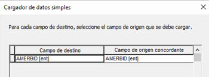

Finalmente, debe seleccionar si desea cargar toda la información o si requiere solo una parte según una selección por atributos (mediante SQL).

Realizado esto, seleccione Finalizar y revise si la información fue cargada adecuadamente.

### 4.2.- Importación

Además de agregar datos de forma manual creando las estructuras correspondientes, las herramientas de administración de la GDB le permiten importar datos de manera directa de manera singular (mayor control) y de manera múltiple (menor control).

Para este proceso considere los archivos alojados en la carpeta **Importación** alojada en su directorio de trabajo. En primera instancia cree un feature dataset de nombre **Importacion**, para alojar los elementos a importar. Para las propiedades del feature dataset considere las mismas que las del feature dataset AMERB.

Realice clic derecho sobre el feature dataset y seleccione **Importar/Clase de entidad (simple)**.

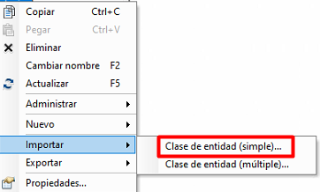

En la ventana que se despliega, debe seleccionar el archivo único **PART_SSP_PT_CALETASARTESANALES.shp**. El directorio de salida se selecciona automáticamente, debe indicar el nombre del feature (el mismo para este caso), puede realizar una selección SQL para filtrar registros de interés (**Expresión**) y modificar las características (nombres, longitud del campo, tipo de dato, alias, etc.) en la sección **Mapa de campo**.

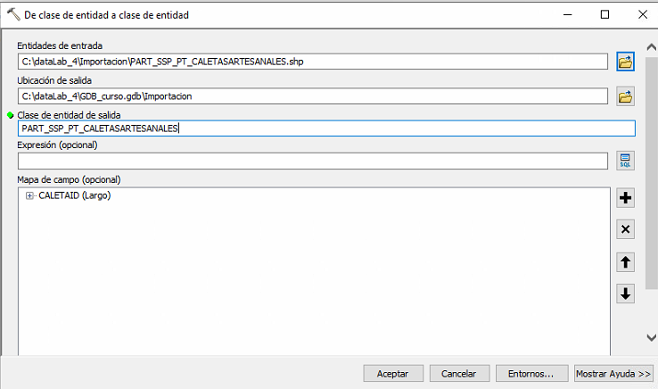

Revise que la capa se importó correctamente.

Repita el proceso pero esta vez seleccione **Feature class (multiple)** y emplee los otros archivos en la carpeta **Importación**.

Note que dispone de menos configuración de los elementos importados, por lo cual si está trabajando con una base ya existente, los elementos a importar deben cumplir con la estructura predeterminada de la base de datos.

### 4.3.- Tablas

La creación de tablas puede realizarse de la misma forma que la creación de los feature class, es decir, manualmente o mediante importación directa (single o múltiple). Es importante destacar que las tablas solo pueden ser creadas o importadas al directorio raíz de la base de datos y no en un feature dataset.

### 4.4.- Relaciones de clase

Las clases de relación en la geodatabase administran las asociaciones entre los objetos de una clase (feature class o tabla) y de otra. Los objetos en cualquier extremo de la relación pueden ser entidades con geometría o registros en una tabla.

Para este ejercicio importe la tabla de nombre **PART_SNP_T_CAPTURA_2010_2014.dbf**, alojada en su directorio de trabajo.

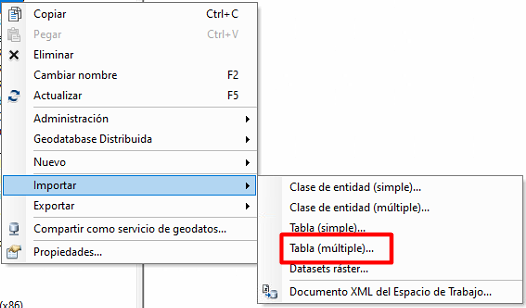

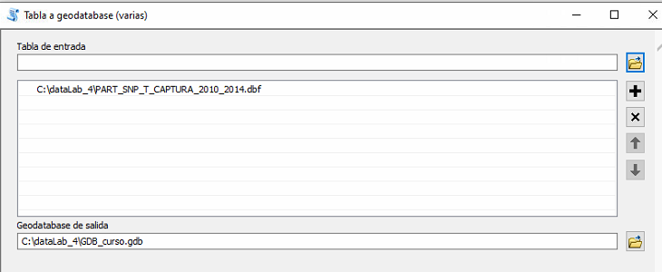

Dado que la relación de clases se puede establecer entre diferentes objetos, puede ser alojada en el directorio raíz o almacenada en un feature dataset donde se aloje la capa geométrica (punto, línea o polígono). De clic derecho sobre el feature dataset de nombre *Importacion* creado anteriormente y seleccione vaya a **Nuevo/Clase de relación**.

Lo primero, consiste en definir el nombre de la relación de clases. Si dispone de un protocolo de almacenamiento puede emplearlo. Para este ejemplo el nombre será **CAPTURA2010_2014**; considere las capas que serán el origen y el destino de la relación. Esto dependerá de la información almacenada y la función de la relación de clases en la base de datos.

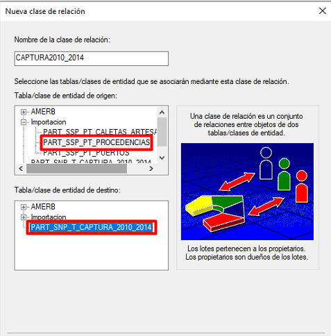

En la selección del tipo de relación (simple o compuesta), también se debe considerar la naturaleza (origen y tipo) de los datos y la funcionalidad o integridad de la base de datos general . Para el ejemplo la relación será de tipo simple (objetos independientes entre sí).

En la siguiente ventana se pueden especificar etiquetas, en caso de no querer emplear los nombres originales de los objetos en la relación. Además, se puede configurar el sentido de propagación de los mensajes, considerando la intención de la relación de clases estipulada. Seleccione la opción **Ambos**.

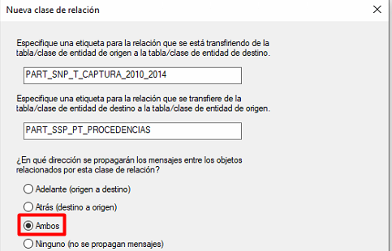

Ahora, seleccione la cardinalidad: uno a uno, uno a muchos o muchos a muchos. Para el ejemplo, la unión correspondería a uno a muchos dado que son las mismas procedencias pero para diferentes registros temporales de captura.

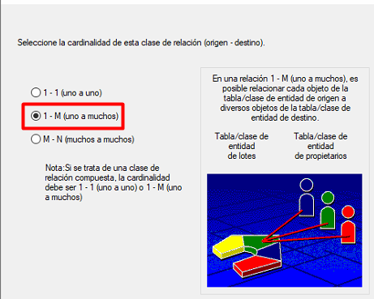

Finalmente, puede elegir agregar atributos a la relación de clases en caso de cualquier otro cálculo u otro elemento de análisis derivado. Esto generaría, de ser creado, una tabla nueva en la GDB. Selección la opción no.

La configuración final implica elegir el código de vinculación entre ambos objetos de la relación. Idealmente, prefiera trabajar o configurar los campos para tener los mismos nombres para asegurar consistencia entre los objetos. En este ejemplo el campo de vinculación es **PROCID**.

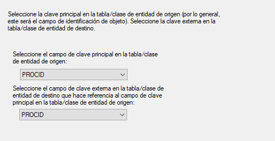

Luego aparecerá un pequeño resumen, si está todo ok, de finalizar para crear la relación. A partir de esta relación usted podrá realizar consultas en su interfaz de ArcMap para escritorio.

### 4.5.- Topología

La topología define cómo las entidades de puntos, líneas y polígonos comparten una geometría coincidente. Pudiendo también ser trabajada en ambiente ArcMap. Por ejemplo, las líneas ejes de calles y las manzanas tienen una geometría común y los polígonos de suelo adyacentes tienen límites comunes.

Para el ejemplo, proceda a importar la capa de nombre **PART_SSP_POLY_AMERB.shp** alojada en su directorio, al feature dataset de nombre **AMERB**. Importada la capa, de clic derecho sobre el feature dataset y seleccione **Nuevo/Topología**.

Lo primero es definir un nombre y tolerancia para la topología; la tolerancia puede ser determinada a partir de criterios empíricos relacionados con la unidad mínima de análisis o basarse en criterios de escala de las capas consideradas. Para el ejemplo mantenga la configuración como aparece en la imagen.

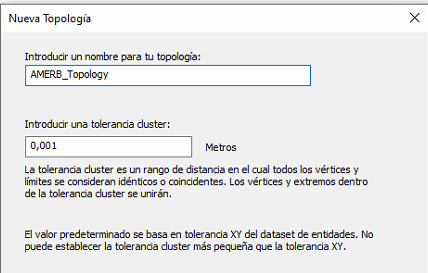

En la siguiente ventana debe seleccionar qué elementos dentro del feature dataset participarán de la topología. Luego, puede ajustar el ranking que define que capa será más o menos importante (se moverá más o menos) en el arreglo topológico. Esto, puede definirlo de acuerdo al fin último de su análisis, las capas dominantes y otros elementos de carácter empírico.

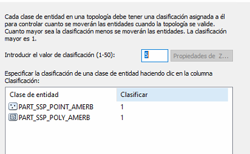

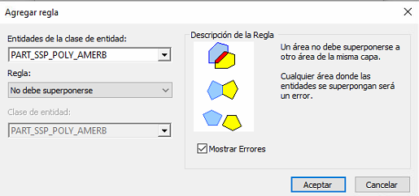

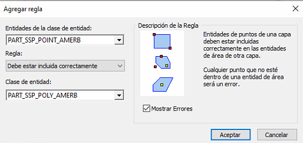

Finalmente, aparecerá un resumen de la topología y los parámetros considerados. Esta topología se guardará como un elemento dentro de la base de datos y podrá ser empleada posteriormente para análisis sobre las capas en el ambiente de ArcMap (según licencias disponibles).

## 5.- Exportación

Adicional a la importación, usted puede exportar a diferentes formatos las capas alojadas en un GDB (personal, file o corporativo) con el fin de compartir con otras plataformas como CAD u algún SIG que no disponga de soporte para GDB. La operación puede ser realizada sobre un solo feature class o un conjunto de ellos.

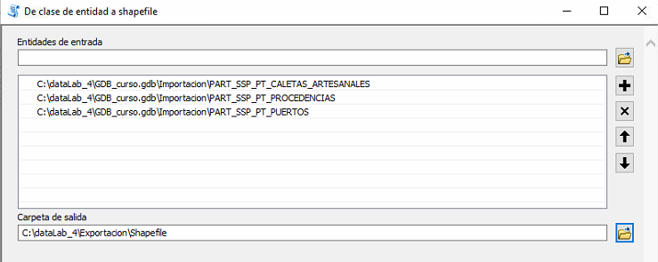

## 6.- Configuración de tablas en base a dominios

Para este ejemplo se trabajará con el dominio ya incorporado en la GDB en el punto 2; correspondiente a **RECURSOS**.

La configuración de los dominios en feature class y tablas dentro de un GDB se realiza de la misma forma, es decir, se puede asignar al momento de crear los elementos (con los dominios ya dispuestos en la GDB) o asignándolos posteriormente.

Para este ejemplo, trabajará con la tabla **PART_SNP_T_CAPTURA_2010_2014** cargada en los procesos anteriores realizados en la guía.

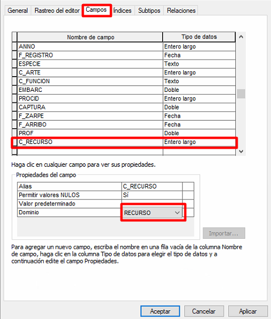

Realizada la acción, acepte los cambios. En el catálogo usted no verá cambio alguno en la tabla. Para visualizar los cambios asociados estos se generan en el ambiente de escritorio de ArcMap.

Esto permite que al agregar nuevos elementos mediante edición, disminuyan errores típicos del trabajo con bases de datos como: diferencia de nombres, uso de acentos, mayúsculas, minúsculas y otros problemas de tipeo.

Se pueden crear tantos dominios como se requieran para la estandarización adecuada de la GDB.

## 7.- Configuración de metadatos

La documentación de los archivos dentro de una base de datos para una posterior distribución de la información resulta relevante para conocer los antecedentes del levantamiento, escalas y otros que puedan ser de interés para el usuario final.

Estos metadatos en chile se rigen por lo que establece IDE Chile en sus normativas (http://www.ide.cl/). Esto puede ser trabajado desde el ambiente de ArcCatalog configurando las normas de los metadatos.

Para esto, diríjase a la barra de tareas y localice la opción **Personalizar/Opciones de ArcCatalog**.Vaya a la pestaña **Metadata** y seleccione **North American Profile of ISO 19115 2003**. Asegúrese que las pestañas estén marcadas como en la imagen.

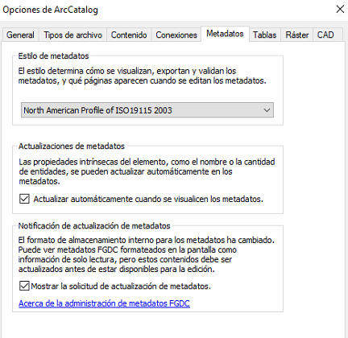

Configurado el protocolo de metadato; seleccione algún elemento dentro del GDB y vaya a la pestaña **Descripción**. En esta sección usted puede editar, validar exportar e importar la metadata de los elementos seleccionados y ajustarla a diferentes protocolos.

Active la edición del elemento y genere una descripción ficticia del mismo reemplazando la existente.

[figure not shown]

Finalizadas las modificaciones, guarde los cambios y ya habrá documentado la información.

## 8.- Exportar y compartir GDB

Usted puede compartir su geodatabase de manera convencional navegando hasta el directorio donde se encuentra alojada y puede usar un compresor (7-Zip, WinRAR) y enviarla directamente.

La forma más completa, asegurando la integridad de los datos consiste en transformar el GDB, ya sea su estructura y datos o solo su estructura, a formato XML. Para realizarlo, vaya en el árbol de navegación de ArcCatalog y de clic derecho sobre su GDB y localice *Exportar/Documento XML del espacio de trabajo*.

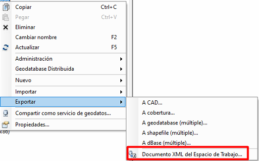

En la ventana debe elegir que desea exportar, en este caso los datos alojados. Dependiendo del número de archivos y tamaño del GDB usted puede optar por distintos modelos de codificación de datos, para este ejemplo elija **Binario**. Guarde el resultado en su directorio y asegúrese de exportar los metadatos.

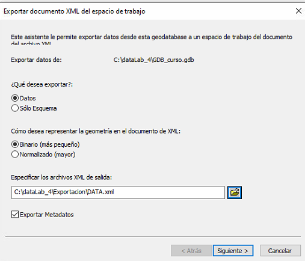

En la siguiente ventana puede elegir que elementos serán transformados al archivo XML, en este caso deje todos los elementos incorporados.

La utilidad de este tipo de exportación radica en que se puede crear otro GDB e importar los datos directamente, manteniendo estructura, configuración de dominios y metadata en caso de existir. Cree en su directorio un nuevo FileGDB vacío, de clic derecho sobre el y localice **Importar/Documento XML del espacio de trabajo**. Localice el archivo XML creado en los pasos anteriores y marque la opción **Datos**.

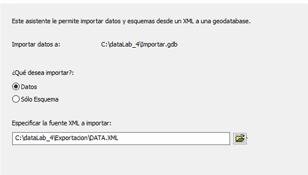

En la siguiente ventana se mostrarán los elementos que se importarán y también algún conflicto de nombres en caso de que exista.